# Exercise Data Analysis

Sarthak Naithani

10/17/2020

# Practical Machine Learning Course Project Report

Developer: **Sarthak Naithani**  
GitHub Repo: https://github.com/100sarthak100/PracticalMachineLearning

## Background

These days there are all kinds of wearable devices like Fitbit, Apple watch, Nike watch etc. It is now possible to collcet large amount of data about physical activities. In this project we will get some insights from these data of the candidates by doing some analyses.

## Data Sources

The training data for this project is available at this url:  
https://d396qusza40orc.cloudfront.net/predmachlearn/pml-training.csv  
The test data is available at this url:  
https://d396qusza40orc.cloudfront.net/predmachlearn/pml-testing.csv

## Intended Results

The goal of this project is to predict the manner in which the people did the exercise using all the data from these wearables.

## Reproducibility

We will be using soem packages, and will be setting some global variables.

```r
library(rattle)
library(caret)
```

```r
library(rpart)
library(rpart.plot)
library(corrplot)
library(randomForest)
```

```r
library(RColorBrewer)
```

Finally, load the seed using following code:

```r
set.seed(56879)
```

Download the dataset to the `data` folder :

```r
trainLink <-"https://d396qusza40orc.cloudfront.net/predmachlearn/pml-training.csv"
testLink <- "https://d396qusza40orc.cloudfront.net/predmachlearn/pml-testing.csv"
trainCsv <- "./data/pml-training.csv"
testCsv  <- "./data/pml-testing.csv"
if (!file.exists("./data")) {
  dir.create("./data")
}
if (!file.exists(trainCsv)) {
  download.file(trainLink, destfile = trainCsv, method = "curl")
}
if (!file.exists(testCsv)) {
  download.file(testLink, destfile = testCsv, method = "curl")
}
rm(trainLink)
rm(testLink)
```

## Reading Data

Reading the two csv files into the dat frame.

```r
trainData <- read.csv(trainCsv)
testData <- read.csv(testCsv)
dim(trainData)
```

```
## [1] 19622   160
```

```r
dim(testData)
```

```
## [1]  20 160
```

```r
rm(trainCsv)
rm(testCsv)
```

The training data contains 19622 observations and 160 variables, while the testing data contains 20 observations and 160 variables. We have to predict `classe` variable.

## Cleaning Data

Cleaning the data set and getting rid of the missing values.

1. Clean the **Near Zero Variance** Variables from the datset.

```r
val <- nearZeroVar(trainData, saveMetrics = TRUE)
head(val, 20)
```

```
##                        freqRatio percentUnique zeroVar   nzv
## X                       1.000000  100.00000000   FALSE FALSE
## user_name               1.100679    0.03057792   FALSE FALSE
## raw_timestamp_part_1    1.000000    4.26562022   FALSE FALSE
## raw_timestamp_part_2    1.000000   85.53154622   FALSE FALSE
## cvtd_timestamp          1.000668    0.10192641   FALSE FALSE
## new_window             47.330049    0.01019264   FALSE  TRUE
## num_window              1.000000    4.37264295   FALSE FALSE
## roll_belt               1.101904    6.77810621   FALSE FALSE
## pitch_belt              1.036082    9.37722964   FALSE FALSE
## yaw_belt                1.058480    9.97349913   FALSE FALSE
## total_accel_belt        1.063160    0.14779329   FALSE FALSE
## kurtosis_roll_belt   1921.600000    2.02323922   FALSE  TRUE
## kurtosis_picth_belt   600.500000    1.61553358   FALSE  TRUE
## kurtosis_yaw_belt      47.330049    0.01019264   FALSE  TRUE
## skewness_roll_belt   2135.111111    2.01304658   FALSE  TRUE
## skewness_roll_belt.1  600.500000    1.72255631   FALSE  TRUE
## skewness_yaw_belt      47.330049    0.01019264   FALSE  TRUE
## max_roll_belt           1.000000    0.99378249   FALSE FALSE
## max_picth_belt          1.538462    0.11211905   FALSE FALSE
## max_yaw_belt          640.533333    0.34654979   FALSE  TRUE
```

```r
train01 <- trainData[, !val$nzv]
test01 <- testData[, !val$nzv]
dim(train01)
```

```
## [1] 19622   100
```

```r
dim(test01)
```

```
## [1]  20 100
```

```r
rm(trainData)
rm(testData)
rm(val)
```

2. Removing some columns of the dataset that do not contribute to our analysis.

```r
reg <- grepl("^X|timestamp|user_name", names(train01))
train <- train01[, !reg]
test <- test01[, !reg]
rm(reg)
rm(train01)
rm(test01)
dim(train)
```

```
## [1] 19622    95
```

```r
dim(test)
```

```
## [1] 20 95
```

3. Removing columns that contain `NA's` values.

```r
col <- (colSums(is.na(train)) == 0)
train <- train[, col]
test <- test[, col]
rm(col)
```

The cleaned training data contains 19622 observations and 54 variables, while the testing data contains 20 observations and 54 variables.

Correlation Matrix of Columns in the Training Data set is.

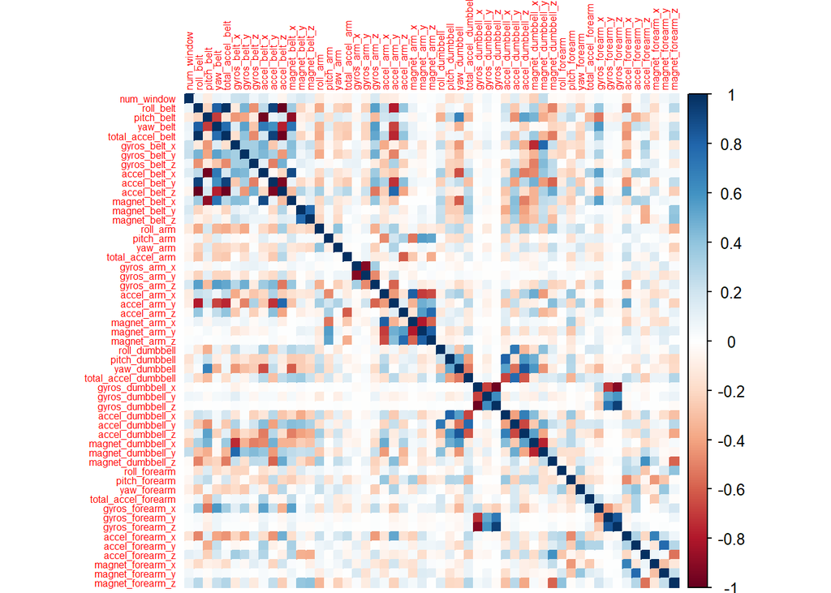

```r
corrplot(cor(train[, -length(names(train))]), method = "color", tl.cex = 0.5)
```

## Partitioning Training Set

We split the cleaned training data into 2 parts with 70% as training set and 30% as validation set.

```r
set.seed(5679) # For reproducibile purpose
inTrain <- createDataPartition(train$classe, p = 0.70, list = FALSE)
valid <- train[-inTrain, ]
train <- train[inTrain, ]
rm(inTrain)
```

The Data now consists of 54 variables with the observations divided as following:  
1. Training Data: 13737 observations.  
2. Validation Data: 5885 observations.  
3. Testing Data: 20 observations.

## Data Modelling

### Decision Tree

We use **Decision Tree** algo to create a model.

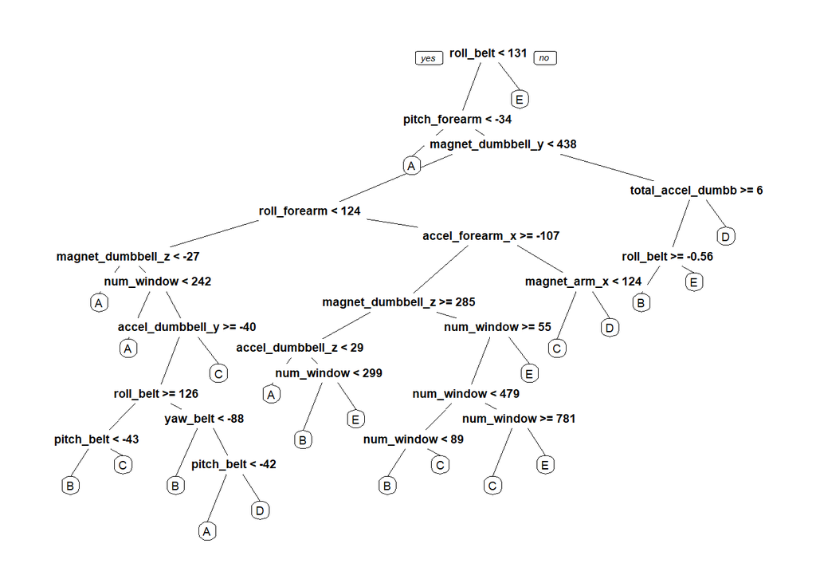

```r
treeModel <- rpart(classe ~ ., data = train, method = "class")
prp(treeModel)
```

Estimating the performance of the model on the **validation** data.

```r
treePredict <- predict(treeModel, valid, type = "class")
confusionMatrix(valid$classe, treePredict)
```

```
## Confusion Matrix and Statistics
##
##           Reference
## Prediction    A    B    C    D    E
##          A 1531  101    9   30    3
##          B  264  660  147   55   13
##          C   51  106  808   61    0
##          D  111  119  110  604   20
##          E   79   83   17   99  804
##
## Overall Statistics
##
##                Accuracy : 0.7489
##                  95% CI : (0.7376, 0.7599)
##     No Information Rate : 0.346
##     P-Value [Acc > NIR] : < 2.2e-16
##
##                   Kappa : 0.6798
##
##  Mcnemar's Test P-Value : < 2.2e-16
##
## Statistics by Class:
##
##                      Class: A Class: B Class: C Class: D Class: E
## Sensitivity            0.7520   0.6174   0.7406   0.7114   0.9571
## Specificity            0.9628   0.9005   0.9545   0.9285   0.9449
## Pos Pred Value         0.9146   0.5795   0.7875   0.6266   0.7431
## Neg Pred Value         0.8801   0.9138   0.9418   0.9502   0.9925
## Prevalence             0.3460   0.1816   0.1854   0.1443   0.1427
## Detection Rate         0.2602   0.1121   0.1373   0.1026   0.1366
## Detection Prevalence   0.2845   0.1935   0.1743   0.1638   0.1839
## Balanced Accuracy      0.8574   0.7590   0.8476   0.8200   0.9510
```

```r
accuracy <- postResample(treePredict, valid$classe)
os <- 1 - as.numeric(confusionMatrix(valid$classe, treePredict)$overall[1])
rm(treePredict)
rm(treeModel)
```

### Random Forest

We use a **Random Forest** predictive model for activity recognition.

```r
rfModel <- train(classe ~ ., data = train, method = "rf", trControl = trainControl(method = "cv", 5), ntree = 250)
rfModel
```

[output not shown]

Now, we estimate the performance of the model on the **validation** data set.

```r
rfPredict <- predict(rfModel, valid)
confusionMatrix(valid$classe, rfPredict)
```

```
## Confusion Matrix and Statistics
##
##           Reference
## Prediction    A    B    C    D    E
##          A 1674    0    0    0    0
##          B    2 1135    1    1    0
##          C    0    4 1022    0    0
##          D    0    0    5  956    3
##          E    0    0    0    4 1078
##
## Overall Statistics
##
##                Accuracy : 0.9966
##                  95% CI : (0.9948, 0.9979)
##     No Information Rate : 0.2848
##     P-Value [Acc > NIR] : < 2.2e-16
##
##                   Kappa : 0.9957
##
##  Mcnemar's Test P-Value : NA
##
## Statistics by Class:
##
##                      Class: A Class: B Class: C Class: D Class: E
## Sensitivity            0.9988   0.9965   0.9942   0.9948   0.9972
## Specificity            1.0000   0.9992   0.9992   0.9984   0.9992
## Pos Pred Value         1.0000   0.9965   0.9961   0.9917   0.9963
## Neg Pred Value         0.9995   0.9992   0.9988   0.9990   0.9994
## Prevalence             0.2848   0.1935   0.1747   0.1633   0.1837
## Detection Rate         0.2845   0.1929   0.1737   0.1624   0.1832
## Detection Prevalence   0.2845   0.1935   0.1743   0.1638   0.1839
## Balanced Accuracy      0.9994   0.9978   0.9967   0.9966   0.9982
```

```r
accuracy <- postResample(rfPredict, valid$classe)
os <- 1 - as.numeric(confusionMatrix(valid$classe, rfPredict)$overall[1])
rm(rfPredict)
```

The Estimated Accuracy of the Random Forest Model is 99.6601529% and the Estimated Out-of-Sample Error is 0.3398471%.  
Random Forests yielded better Results, as expected!

## Predicting The Manner of Exercise for Test Data Set

```r
rm(accuracy)
rm(os)
predict(rfModel, test[, -length(names(test))])
```

```
##  [1] B A B A A E D B A A B C B A E E A B B B
## Levels: A B C D E
```

## Generating Files

```r
write_files = function(x){
  n = length(x)
  for(i in 1:n){
    filename = paste0("./problem_id_",i,".txt")
    write.table(x[i], file = filename, quote = FALSE, row.names = FALSE, col.names = FALSE)
  }
}
```

```r
write_files(predict(rfModel, test[, -length(names(test))]))
rm(rfModel)
rm(train)
rm(test)
rm(valid)
rm(write_files)
```